# Iris Data

Mike McPhee Anderson

December 21, 2018

## Iris Data Set

The iris (flower) dataset is commonly used for classification problems. The objective is to identify the iris’s *species* based upon measurements of the *sepal* and *petal*. Summary of the dataset is below:

```
##   Sepal.Length    Sepal.Width     Petal.Length    Petal.Width          Species
##  Min.   :4.300   Min.   :2.000   Min.   :1.000   Min.   :0.100   setosa    :50
##  1st Qu.:5.100   1st Qu.:2.800   1st Qu.:1.600   1st Qu.:0.300   versicolor:50
##  Median :5.800   Median :3.000   Median :4.350   Median :1.300   virginica :50
##  Mean   :5.843   Mean   :3.057   Mean   :3.758   Mean   :1.199
##  3rd Qu.:6.400   3rd Qu.:3.300   3rd Qu.:5.100   3rd Qu.:1.800
##  Max.   :7.900   Max.   :4.400   Max.   :6.900   Max.   :2.500
```

## Visualization

### Basic Clustering

Start by clustering based on size. Both the Sepal and Petal have length and width; perform a dimensionality reduction by converting this to be a size. Two new attributes will be added, “Sepal.Size” and “Petal.Size”.

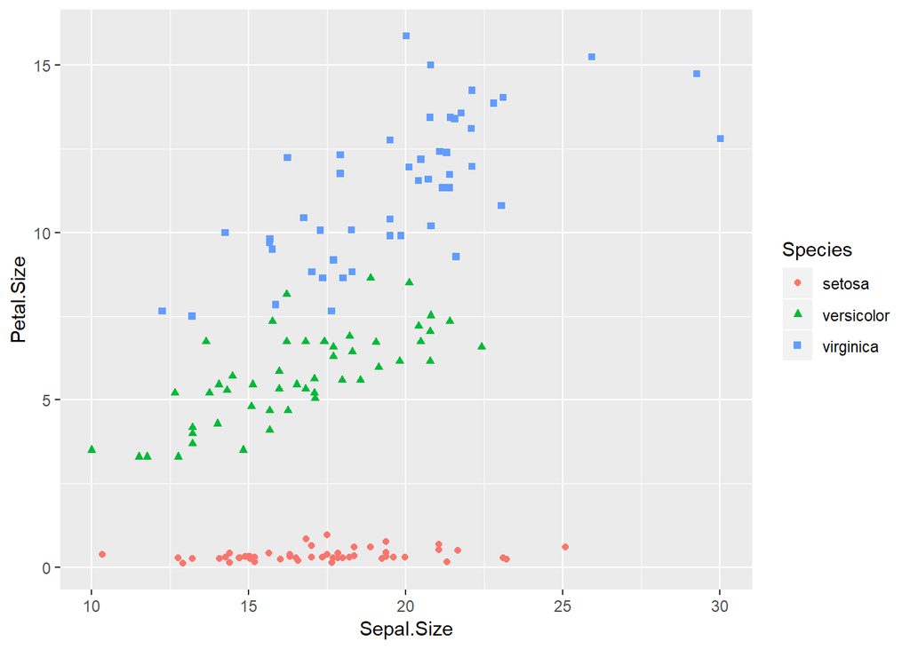

That worked pretty well, it’s apparent that the *setosa* has a small petal size, and *virginica* has a large petal size. We’ll add preliminary lines to mimic the rules that a decision tree might find. It appears that Petal size is a good predictor

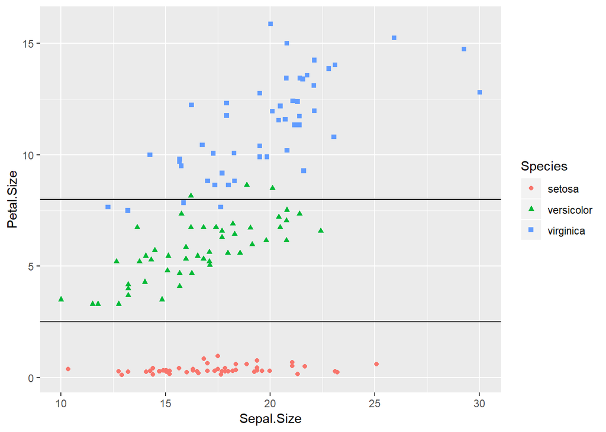

```r
# Plot it with an "eye-balled" decision boundary on Petal.Size
ggplot(iris, aes(x=Sepal.Size, y=Petal.Size, col=Species, shape=Species)) +
  geom_point() +
  geom_hline(yintercept = 8) +
  geom_hline(yintercept = 2.5)
```

## Classification Models

### Decision Tree

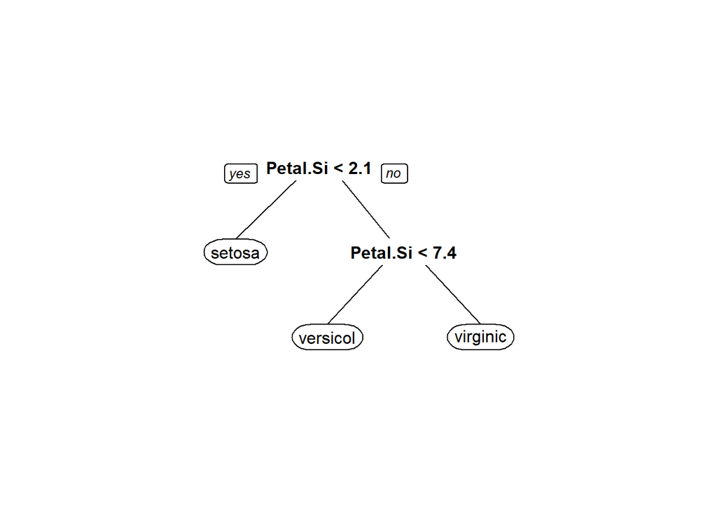

```r
# create holdout set
trainIdx <- as.vector(
  createDataPartition(iris$Species, p=.80, list=FALSE))

iris.train <- iris[trainIdx,]
iris.test <- iris[-trainIdx,]

# five folds, repeated 3 times
trCtrl <- trainControl(method="cv", number=4)

# tuneLength is the number of attempts made to adjust the model's "tuning" parameter,
# in this case it is the "complexity" of the decision tree, e.g. gini information gain
treeFit <- train(Species ~ Petal.Size, data=iris.train,
                 method="rpart",
                 trControl=trCtrl,
                 tuneLength=10)

# plot the tree
prp(treeFit$finalModel)
```

```r
# final error rate
iris.test$predict <- predict(treeFit$finalModel, iris.test, type="class")

dtreeErrorRate <- 1 - sum(iris.test$predict == iris.test$Species)/nrow(iris.test)
```

### Decision Tree results

The final error rate on the validation set is 3.33%.